# Data visualization with Pandas

Pandas implements some high level plotting functions using matplotlib. **Note** If you have seaborn imported, pandas will relay the plotting through seaborn and you get better looking plots for the same data and commands.

```python
import pandas as pd
import numpy as np
%matplotlib inline
import matplotlib.pyplot as plt
import seaborn as sns
```

## Read some data

```python
df1 = pd.read_csv('/Users/atma6951/Documents/code/pychakras/pychakras/udemy_ml_bootcamp/Python-for-Data-Visualization/Pandas Built-in Data Viz/df1', index_col=0)
df2 = pd.read_csv('/Users/atma6951/Documents/code/pychakras/pychakras/udemy_ml_bootcamp/Python-for-Data-Visualization/Pandas Built-in Data Viz/df2')
```

```python
df1.head()
```

|  | A | B | C | D |
| --- | --- | --- | --- | --- |
| 2000-01-01 | 1.339091 | -0.163643 | -0.646443 | 1.041233 |
| 2000-01-02 | -0.774984 | 0.137034 | -0.882716 | -2.253382 |
| 2000-01-03 | -0.921037 | -0.482943 | -0.417100 | 0.478638 |
| 2000-01-04 | -1.738808 | -0.072973 | 0.056517 | 0.015085 |
| 2000-01-05 | -0.905980 | 1.778576 | 0.381918 | 0.291436 |

```python
df2.head()
```

|  | a | b | c | d |
| --- | --- | --- | --- | --- |
| 0 | 0.039762 | 0.218517 | 0.103423 | 0.957904 |
| 1 | 0.937288 | 0.041567 | 0.899125 | 0.977680 |
| 2 | 0.780504 | 0.008948 | 0.557808 | 0.797510 |
| 3 | 0.672717 | 0.247870 | 0.264071 | 0.444358 |
| 4 | 0.053829 | 0.520124 | 0.552264 | 0.190008 |

## 3 ways of calling plot from a DataFrame

- `df.plot()` and specify the plot type, the X and Y columns etc
- `df.plot.hist()` calling plot in OO fashion. Only specify teh X and Y and color or size columns
- `df['column'].plot.plotname()` - calling plot on a series

Types of plot that can be called: area, bar, line, scatter, box, hexbin, kde etc.

### Ways of plotting histogram

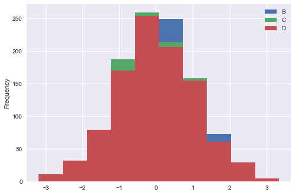

```python
df1.plot(x='A', kind='hist')
```

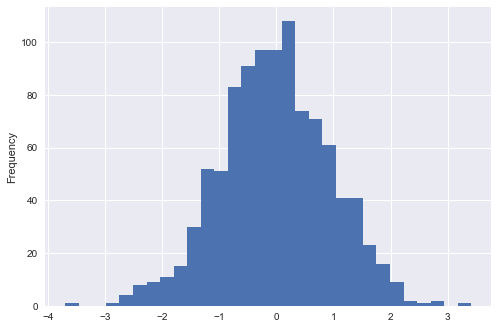

```python
df1['A'].plot.hist(bins=30)
```

### Plotting a histogram of all numeric columns in the dataframe:

[output not shown]

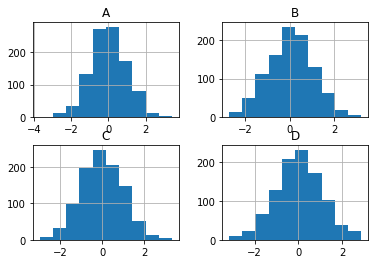

```python
df1.hist()
```

In reality, you have a lot more columns. You can prettify the above by creating a layout and figsize:

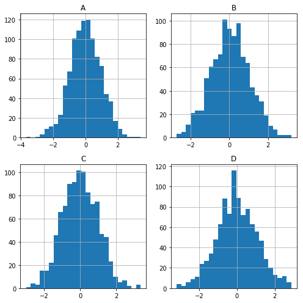

```python
ax_list = df1.hist(bins=25, layout=(2,2), figsize=(7,7))
plt.tight_layout()
```

### Plotting histogram of all columns and sharing axes

The chart above might make more sense if you shared the X as well as Y axes for different columns. This helps in comparing the distribution of values visually.

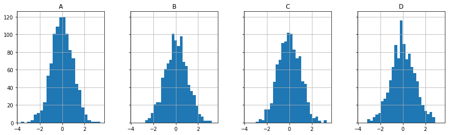

```python
ax_list = df1.hist(bins=25, sharex=True, sharey=True, layout=(1,4), figsize=(15,4))
```

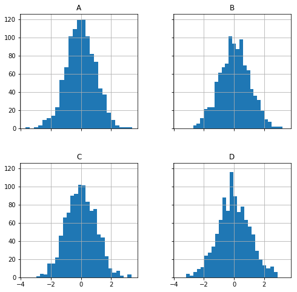

```python
ax_list = df1.hist(bins=25, sharex=True, sharey=True, layout=(2,2), figsize=(8,8))
```

## Backgrounds

You can specify dark or white background and style info to the matplotlib that is used behind the scenes.

### Area plot

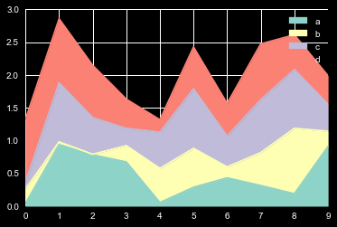

```python
plt.style.use('dark_background')
df2.plot.area()
```

### Bar chart

Another style is `fivethirtyeight`

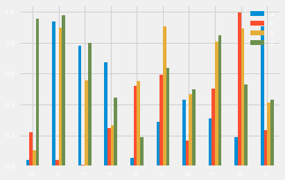

```python
plt.style.use('fivethirtyeight')
df2.plot.bar()
```

### Line plot

This is suited for time series data

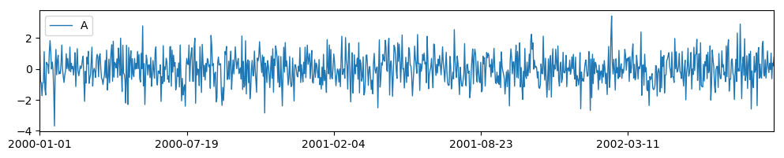

```python
#reset the style
plt.style.use('default')

# pass figsize to the matplotlib backend engine and `lw` is line width
df1.plot.line(x=df1.index, y='A', figsize=(12,2), lw=1)
```

### Scatter plot

Use `colormap` or `size` to bring in a visualize a 3rd variable in your scatter

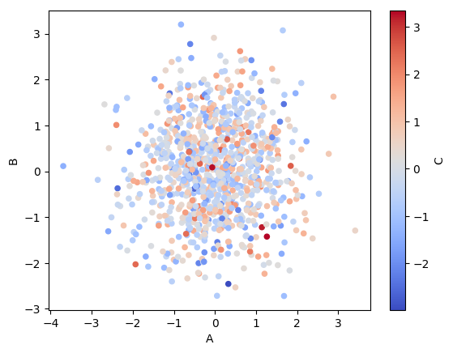

```python
df1.plot.scatter(x='A', y='B',c='C', cmap='coolwarm')
```

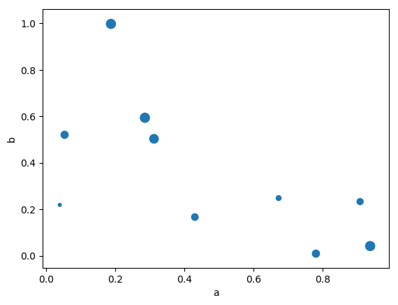

```python
# you could specify size s='c' however the points come out tiny.
# had to scale it by 100, hence using actual series data and not the column name
df2.plot.scatter(x='a',y='b', s=df2['c']*100)
```

### KDE plots

To visualize the density of data

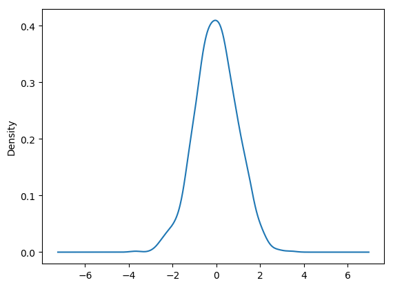

```python
df1['A'].plot.kde()
```

Visualize the density of all columns in one plot

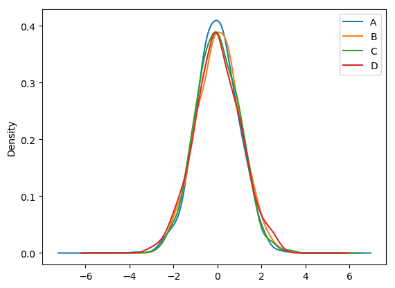

```python
df1.plot.kde()
```

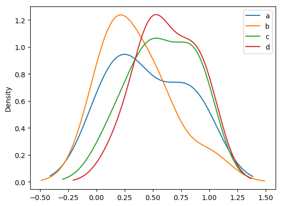

```python
df2.plot.density() #I think density is an alias to KDE
```